# !!PAGE UNDER CONSTRUCTION!! Recommender Systems: A Little Bit of Everything

Joseph Bolton

09 December 2022

The majority of the content in this resource is from the book *Recommender Systems: The Textbook* ((Aggarwal 2016)).

Although I use ‘$r_{ij}=\text{rating of item } j \text{ by user } i$’ as the outcome of interest throughout this document, this can be more generally understood as ‘$\text{affinity for item } j \text{ for user } i$’. The exact outcome of interest will depend on the recommendation context (e.g. the outcome of interest might be ‘*probability of click*’ in a web recommendation context).

# Goals of Recommender Systems

[back to contents]

1. **Relevance**: The primary goal of standard recommender systems is to highlight for each user the subset of items which are most **relevant** to them, meaning those items which they would be most interested in (the items with the most utility to them).

However, there are some important secondary goals that are also very important in many cases:

2. **Novelty**: recommended items should be ones that a user has not seen before (or could not easily find on their own).
3. **Serendipity**: item recommendations should sometimes be unexpected (pleasantly surprising) to the user. Serendipity is “finding valuable or pleasant things that are not looked for.” (Kaminskas and Bridge 2016)

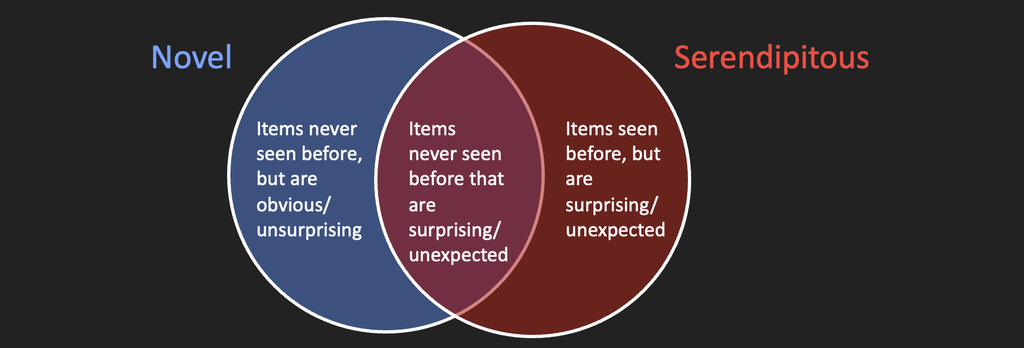

image source: author

4. **Diversity**: “In information retrieval.. [covering] a broad area of the information space increases the chance of satisfying the user’s information need” (Kaminskas and Bridge 2016). This is because the user’s intent is somewhat ambiguous (e.g. whether “bat” refers to an animal or to sporting equipment), and returning diverse results corresponding to the query makes it more likely that the user’s desired item is within the result set. This applies equally to recommender systems: since there is some ambiguity in understanding what the user wants, it is safer not to put all of our eggs into one basket.
5. **Coverage**: “Coverage reflects the degree to which the generated recommendations cover the catalogue of available items” (Kaminskas and Bridge 2016). This is important both for users (it improves the usefulness of the system) and for business-owners (because showing users the same small subset of the item catalogue might impact stock level management of physical items, and also because there has been a societal shift in consumer demand for products in the [long tail](https://en.wikipedia.org/wiki/Long_tail) of the catalogue (Armstrong 2008)).

There is a good discussion of this topic (the multiple goals of recommender systems) and of how these outcomes can be optimized and objectively measured in the paper *Diversity, Serendipity, Novelty, and Coverage: A Survey and Empirical Analysis of Beyond-Accuracy Objectives in Recommender Systems* (Kaminskas and Bridge 2016).

Some further notes:

- I think that there is an important distinction to be made between *search engines* (which are primarily concerned with *information retrieval* - finding an item that you are looking for) and *recommender systems* (which are primarily concerned with *information filtering* - discovering items that you will likely be interested in).
- To go a level deeper: the preference for relevance, novelty, serendipity, diversity and catalogue coverage of recommendations likely differs per user - some users might prefer more narrow/conservative recommendations, while another might prefer more variety.

# Design Patterns

[back to contents]

- **Hyper Personalisation**: Try to guess exactly which subset of items each individual user wants and show it to them.
- **Similar Products**: Show user variants of an item that they are currently browsing/interested in (differing on 1 or more product dimensions) e.g. “same item but cheaper”, “same item but in red”, “similar item from another brand.”
- **Complementary Products**: Recommend items which go well with/add value to/are often bought alongside the user’s current item (or one which they already own).
- **Popular/Trending**: Highlight items popular/trending globally, within a user’s segment, or within the current context (e.g. current time, current season etc.)
- **Product Replenishment**: Predict timing of user need for an item to be renewed/replenished/replaced.
- **Search Engine**: Give users an intelligent system for navigating the item catalogue. See also Knowledge-Based Recommendation Systems.

TODO: need to complete this list!

# Supervised Learning

[back to contents]

The problem of predicting a particular user’s affinity for a particular item can be framed as a supervised learning problem, allowing us to use any one of the available plethora of performant classification, regression or ranking models (generalized linear models, gradient boosting, random forest, deep learning etc.).

The user rating (affinity) for a particular item is modelled as a function of the user’s attributes, the item’s attributes and (possibly) information on the recommendation context:

$$\begin{array}{lcl}
r_{ij} &=& f\Big(\mathbf{x}^{(user)}_i, \mathbf{x}^{(item)}_j,
\mathbf{x}^{(context)}_k\Big) \\
\mathbf{x}^{(user)}_i &=& \text{vector of user attributes} \\
\mathbf{x}^{(item)}_j &=& \text{vector of item attributes} \\
\mathbf{x}^{(context)}_k &=& \text{vector of recommendation
context information} \\
\end{array}$$

A strength of this method is that it can mitigate the recommendation cold start problem (in which recommendations cannot be generated for new users and/or items) by sharing information across users and items.

Some specific examples of recommender architectures based on supervised learning are:

1. Factorization Machines
2. The 2 Tower model
3. The Wide & Deep model
4. The Deep & Cross model

# Content-Based Recommendation

[back to contents]

| user_ID | movie | user_rating | length_hours | origin_country | budget_millions | genre | description | thrilling | exploding | adventure | exotic | drama | love |
| --- | --- | --- | --- | --- | --- | --- | --- | --- | --- | --- | --- | --- | --- |
| 46290 | movie A | 5 | 1.5 | USA | 50 | action | a thrilling exploding adventure | 1 | 1 | 1 | 0 | 0 | 0 |
| 46290 | movie B | 3 | 2.0 | India | 60 | drama | an exotic adventure full of drama | 0 | 0 | 1 | 1 | 1 | 0 |
| 46290 | movie C | 4 | 1.5 | UK | 100 | action | things exploding everywhere | 0 | 1 | 0 | 0 | 0 | 0 |
| 46290 | movie D | 1 | 3.0 | USA | 4 | romance | an american love story drama | 0 | 0 | 0 | 0 | 1 | 1 |

The premise behind *content-based recommendation* is that once a user has consumed multiple items, we can use the attributes of those items to build an item attribute preference profile for that user, and use this profile to recommend future items to them.

For example, in a food recommendation context we might learn that a certain user likes Italian and Indian food, but never orders red meat or chilli.

A content-based strategy is particularly effective in situations in which:

1. There is rich and predictive item attribute data available (structured or raw text)
2. Past user item consumption is predictive of future preferences

Compared to collaborative filtering:

1. content-based recommendation can robustly recommend items with few or no ratings (i.e. it alleviates the cold start problem for new items)
2. content-based recommendation tends to produce more relevant, if also more boring and obvious, recommendations. This is because it cannot recommend items outside of the users historic item attribute consumption (i.e. it won’t recommend items outside of the scope of what they have consumed in the past)

If users are able to explicitly specify their own preferences (like a knowledge-based recommendation system), then this information can be incorporated into their item attribute preference profile.

# Content-Based Recommendation: Nearest-Neighbour Classification

TODO

# Content-Based Recommendation: Raw Text Preprocessing

TODO

# Creating User & Item Characterization Vectors

[back to contents]

TODO

# Collaborative Filtering

[back to contents]

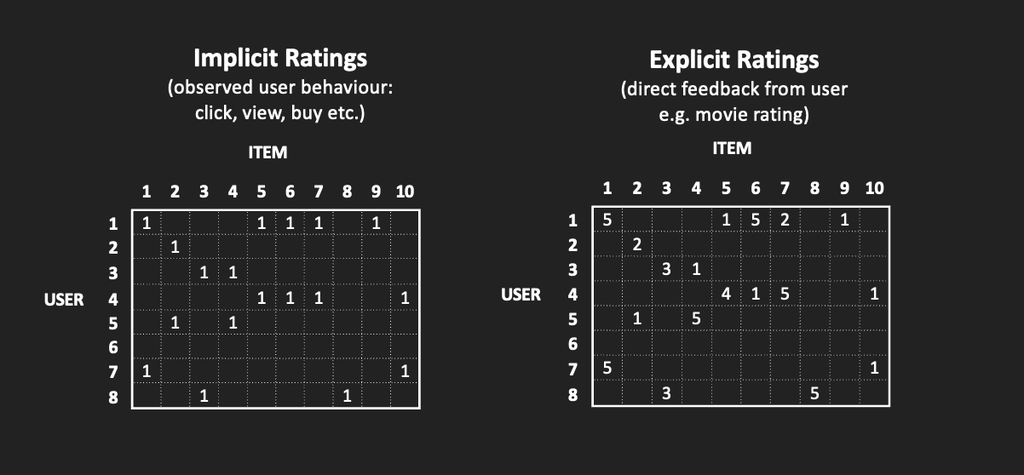

image source: author

[Collaborative Filtering](https://en.wikipedia.org/wiki/Collaborative_filtering) refers, in general, to the process of inferring the unobserved preferences of entities (e.g. users) using the observed preferences of other entities (e.g. other users). It is “collaborative” in the sense that entities (unwittingly) contribute information toward each others recommendations.

- In a recommendation context, this traditionally means inferring the missing entries in a partially observed user/item ratings matrix using the structure among the observed entries in the matrix.
- It sometimes makes sense to preprocess the ratings matrix before making inferences on it e.g. mean-centring ratings within each user to mitigate individual user bias.

## Collaborative Filtering: Neighbourhood: User-User Similarity

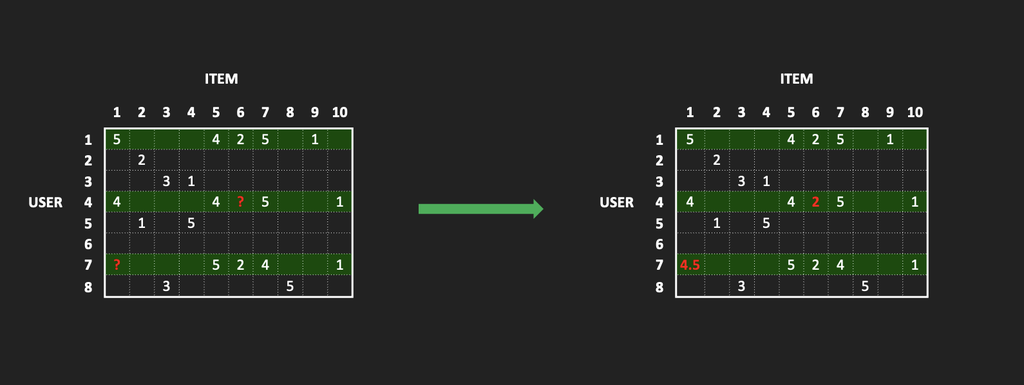

image source: author

- Predict an unobserved rating for item $j$ by user $i$ as the average rating of item $j$ across the $k$ users most similar to user $i$ who have rated item $j$. This average can (if desired) be weighted proportionately to each user’s similarity to user $i$.
- Similarity between users is traditionally defined using the distance between their item rating vectors (i.e. theirs rows in the user/item matrix). Vector distance metrics such as cosine similarity, euclidean distance, manhattan distance etc. can be used for this.
- *‘Closest $k$ neighbours’* can (if desired) be replaced by *‘all neighbours within a distance of d’*.
- Compared to Item-Item Similarity, User-User Similarity tends to produce more serendipitous - if sometimes less relevant - recommendations (see also Combining User-User & Item-Item Similarity).

## Collaborative Filtering: Neighbourhood: Item-Item Similarity

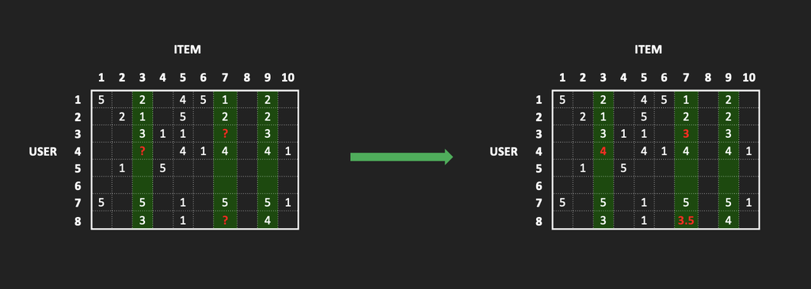

image source: author

  i.e. an unobserved rating for item $j$ by user $i$ is estimated as the average rating by user $i$ over the $k$ most similar items to item $j$ that user $i$ has rated.
- Compared to User-User Similarity, Item-Item Similarity tends to produce more relevant - if sometimes more boring/obvious - recommendations (see also Combining User-User & Item-Item Similarity).

## Collaborative Filtering: Neighbourhood: Combining *User-User* and *Item-Item* Similarity

Since any missing (unobserved) entry $r_{ij}$ in the user/item ratings matrix can be estimated using either User-User Similarity ($\hat{r}_{ij}^{(user)}$) or Item-Item Similarity ($\hat{r}_{ij}^{(item)}$), a given missing entry can also be estimated as a weighted average of the two:

$$\hat{r}_{ij} \quad=\quad \alpha \space
\hat{r}_{ij}^{(user)} + (1-\alpha) \space \hat{r}_{ij}^{(item)}
\quad,\quad\alpha\in[0,1]$$

..where the hyperparameter $\alpha$ can be used to control the balance between recommendation relevance and recommendation serendipity.

## Collaborative Filtering: Matrix Factorization

Matrix factorization refers to the process of learning a low-rank approximation of the user/item ratings matrix, then using this low-rank representation to infer the missing (unobserved) ratings in the matrix.

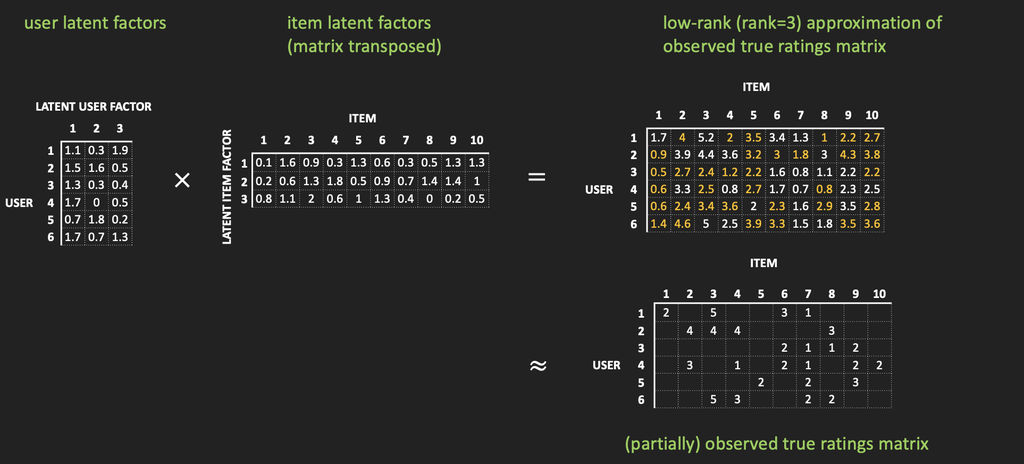

image source: author

For more information, refer to Matrix Factorization (Latent Factor Models)

## Collaborative Filtering: Neighbourhood: Graph-Based

refer to Graph-Based Collaborative Filtering

# Multi-Armed Bandits

[back to contents]

TODO

# Vincent’s Lemma: Serendipity

[back to contents]

This is a simple and heuristic method (created by [Vincent Warmerdam](https://koaning.io)) that was found to substantially increase the coverage of item recommendations in a commercial movie recommendation context.

It is a system for *next item recommendation*.

It shares some conceptual similarities with Association Rules-Based Recommendation

$$\begin{array}{lcl}
R_{j\rightarrow{}i} &=& \text{relative affinity for item } i
\text{ among item } j \text{ consumers compared to the rest of the user
population} \\
&=& \displaystyle\frac{\text{% of item } j \text{ consumers have
also consumed item }i}{\text{% of non-item } j \text{ consumers have
also consumed item }i} \\
&=& \displaystyle\frac{p(s_i\bigl|s_j)}{p(s_i\bigl|s_j^c)} \\
&\approx& \displaystyle\frac{p(s_i\bigl|s_j)}{p(s_i\bigl)} \\
\end{array}$$

For users who have consumed item $j$, the item $i$ with the highest score $R_{j\rightarrow{}i}$ should be recommended to them.

For items with a low amount of user interaction, the $R_{j\rightarrow{}i}$ score will be unstable. This could be alleviated by making the calculation Bayesian, and shrinking the metric using a chosen prior distribution.

# Association Rules-Based Recommendation

[back to contents]

[Association Rules](https://en.wikipedia.org/wiki/Association_rule_learning) are rules of the form

$$\overset{\text{antecedant set}}{\{...\}}
\quad\overset{\text{implies}}{=>} \quad \overset{\text{consequent
set}}{\{...\}}$$

Very efficient algorithms such as the [a priori](https://en.wikipedia.org/wiki/Apriori_algorithm) algorithm have been devised for searching data for rules of this form.

[Association Rules](https://en.wikipedia.org/wiki/Association_rule_learning) are particularly effective in the case of unary ratings.

Here are some of the ways that [association Rules](https://en.wikipedia.org/wiki/Association_rule_learning) can be used to generate item recommendations:

1. **Item-wise Recommendations**:
   - $\overset{\text{item set}}{\{...\}} \quad\overset{\text{implies}}{=>} \quad \overset{\text{item set}}{\{...\}}$
   - Example: $\{\text{bread, tomato}\}=>\{\text{cheese}\}\quad$ i.e. users who have bought *bread* and *tomato* should be recommended *cheese*.
2. **User-wise Recommendations**
   - $\overset{\text{user set}}{\{...\}} \quad\overset{\text{implies}}{=>} \quad \overset{\text{user set}}{\{...\}}$
   - Example: $\{\text{alice, bob}\}=>\{\text{john}\}\quad$ i.e. if users “Alice” and “Bob” have bought bought an item then “John” is also likely to like it
3. **Profile Assocation Rules**:
   - $\overset{\text{user attribute set}}{\{...\}} \quad\overset{\text{implies}}{=>} \quad \overset{\text{item set}}{\{...\}}$
   - Example: $\{\text{male, age30-39, 2_children}\}=>\{\text{home loan}\}\quad$ i.e. a large proportion of male users in their 30s with 2 children have consumed the item “home loan”, making it a promising recommendation for this user segment

# Sequential Pattern Mining

[back to contents]

TODO

# Clustering-Based Recommendation

[back to contents]

TODO

# Graph-Based Collaborative Filtering

[back to contents]

- Sparsity of the observed data in the user/item ratings matrix is problematic for neighbourhood calculation in neighbourhood-based collaborative filtering models. This problem is elegantly solved using graph representations of user/item relationships.
- Relationships between users and items can be cleanly described (and modelled) using graphs, in which nodes represent entities (e.g. user or item) and edges represent relationships between them.
- Graphs define a novel measure of distance (dissimilarity) between entities: the length of a path between them, travelling along edges (either the shortest path, or using a random walk).

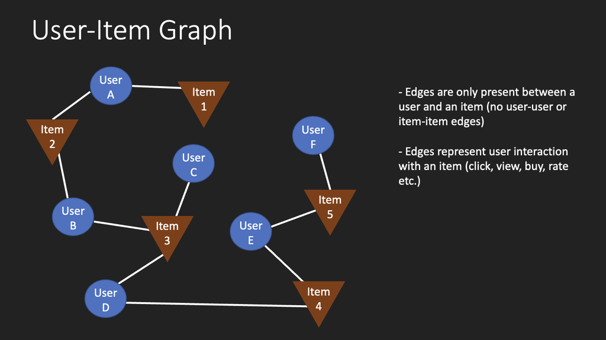

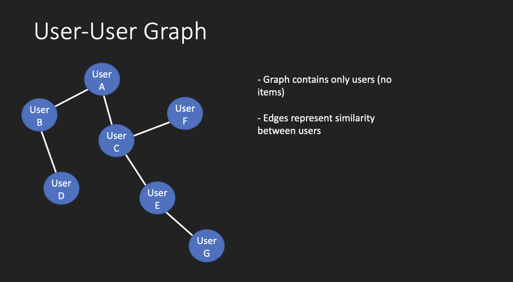

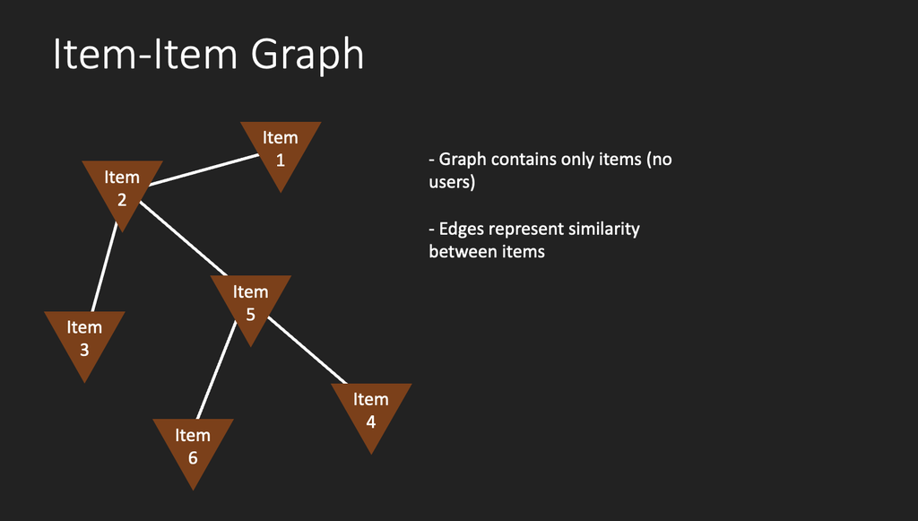

image source: author

- If required, edges can have different weights, describing the strength (and sign) of the connection (relationship) between nodes (entities).
- Graphs are an effective solution to the problem of data sparsity e.g. most users have rated only a tiny proportion of all items, because even users with no items in common can be linked through intermediate users in the graph.
- Graphs structures can be coded directly (e.g. [NetworkX](https://github.com/networkx/networkx)), or using a model (there are MANY deep learning approaches). Model-based methods also facilitate tasks such as link (edge) prediction.

Here is a [lovely resource](https://distill.pub/2021/gnn-intro/) on neural networks for graph modelling.

# Matrix Factorization (Latent Factor Models)

[back to contents]

Matrix factorization refers to the process of learning a low-rank approximation of the user/item ratings matrix then using this low-rank representation to infer the missing (unobserved) ratings in the matrix.

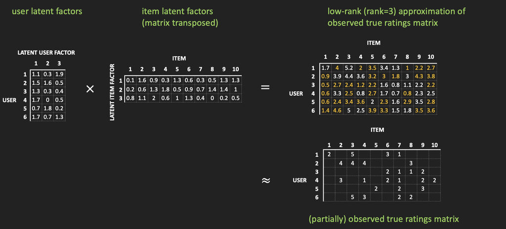

image source: author

There are many different ways in which this matrix factorization can be performed, each of which has various different strengths and weaknesses. These variants are defined by the constraints which they impose on the latent factors. Imposing constraints on the latent factors will always decrease accuracy (increase error) on the observed (training) data, but these constraints can also improve model generalization (error on unobserved data) and increase model interpretability.

Here is a summary of factorization methods from (Aggarwal 2016) -

The Family of Matrix Factorization Methods

| Method | Constraints on factor matrices | Advantages/disadvantages |
| --- | --- | --- |
| Unconstrained | none | Highest quality solution Good for most matrices Regularisation prevents overfitting Poor interpretability |
| Singular Value Decomposition (SVD) | orthogonal basis | Good visual interpretability Out-of-sample recommendations Good for dense matrices Poor semantic interpretability Suboptimal in sparse matrices |
| Maximum Margin | none | Highest quality solution Resists overfitting Similar to unconstrained Poor interpretability Good for discrete ratings |
| Non-Negative Matrix Factorization (NMF) | non-negativity | Good quality solution High semantic interpretability Loses interpretability with both like/dislike ratings Less overfitting in some cases Best for implicit feedback |
| Probabilistic Latent Semantic Analysis (PLSA) | non-negativity | Good quality solution High semantic interpretability Probabilistic interpretation Loses interpretability with both like/dislike ratings Less overfitting in some cases Best for implicit feedback |

# Naïve Bayes Collaborative Filtering

[back to contents]

TODO

# Knowledge-Based Recommendation

[back to contents]

Knowledge-based recommender systems generate recommendations by combining an explicit user query with domain knowledge/algorithmic intelligence (e.g. user attributes, item attributes, historic item consumption data, recommendation context, item availability etc.). In this way, they lie somewhere on the spectrum between a pure queryless [recommender system](https://en.wikipedia.org/wiki/Recommender_system) and a [search engine](https://en.wikipedia.org/wiki/Search_engine).

Knowledge-based recommendation is typically facilitated through an iterative/cyclic exchange between the user and an interactive user interface, for example:

$$\text{user query} >> \text{query
result} >> \text{refined user query} >> \text{refined query
result} >> \text{refined user query} >> \text{refined query
result} >> ...\text{etc. (until user finds a satisfactory
item)}$$

# Hybrid Systems

[back to contents]

TODO

# Tradeoffs Between Different Recommendation Algorithms

[back to contents]

TODO

# Factorization Machines {factorization_machines}

[back to contents]

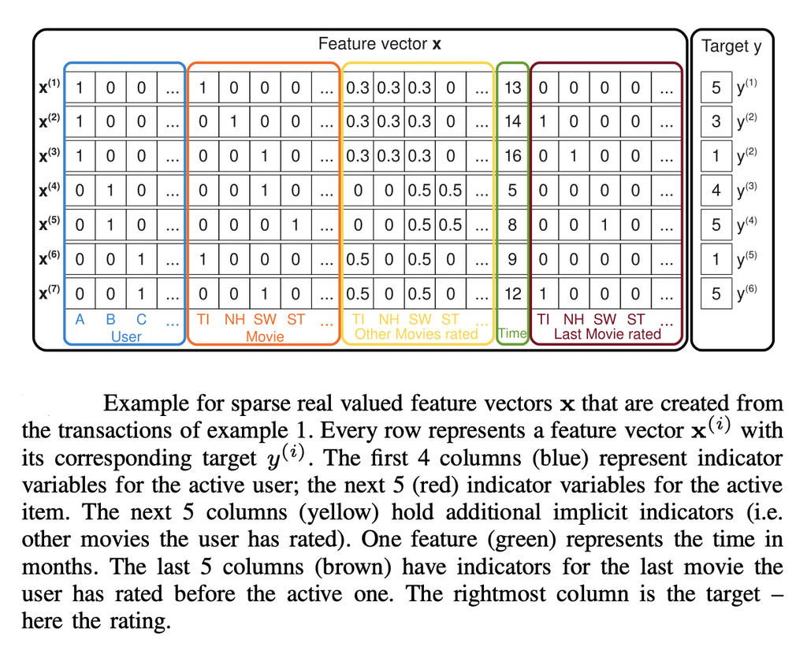

image source: Rendle (2010)

- *Factorization Machines* (Rendle (2010)) are simply linear regression models with interactions, but in which the model coefficients on the interaction terms are modelled using a latent factor model. This factorization helps to avoid overfitting and improve generalization, especially when modelling sparse data. This is achieved by breaking the independence between the interaction coefficients (i.e. allowing/forcing information sharing between them).

The basic model is defined:

$$\begin{array}{lcl}
\hat{y}_i(\overrightarrow{\mathbf{x}}_i) &:=&
\underset{\text{standard linear regression}}{\underbrace{w_0 +
\displaystyle{\sum_{i=1}^p}w_ix_i}} + \underset{\text{latent factor
model of all 2-way
interactions}}{\underbrace{\displaystyle{\sum_{i=1}^p\sum_{j=i+1}^p<\overrightarrow{\mathbf{v}}_i,\overrightarrow{\mathbf{v}}_j>}x_ix_j}}
\\
\space &\space& w_0\in \mathbb{R},
\quad\overrightarrow{\mathbf{w}} \in \mathbb{R}^{p}, \quad \mathbf{V}
\in \mathbb{R}^{p \times k} \\
\end{array}$$

- The hyperparameter $k$ (latent factor dimension) is a parameter to be tuned - it controls the flexibility (constrainedness) of the interaction portion of the model.
- They are suitable for modelling extremely large (e.g. 1 billion rows) and sparse datasets (e.g. recommender engines).
- The model equation can be computed in linear time $O(kp)$ and can be optimized using gradient descent, which makes training feasible for extremely large datasets.
- The model can be extended to capture higher order (e.g. 3-way) interactions (up to arbitrary order).
- The model can be trivially modified in order to solve binary classification or ranking problems.
- *Factorization Machines* are often included as a component/module in a more complex model (e.g. *DeepFM*).

# Incorporating Context

[back to contents]

TODO

# Session-Based Recommendation

[back to contents]

TODO

# Wide & Deep Model

[back to contents]

Inspired by the observation that shallow models (like [linear models](https://en.wikipedia.org/wiki/Generalized_linear_model)) tend to be better at *memorization* (finding specific reoccurring patterns in data) while deep models tend to be better at *generalization* (approximating the structure of the underlying data-generating system), the Wide and Deep (Cheng et al. 2016) model is an architecture containing both a *wide* component and a *deep* component - an attempt to combine the specific strengths of these 2 different models in a unified framework.

Google evaluated this model for app recommendation on their app store [Google Play](https://play.google.com).

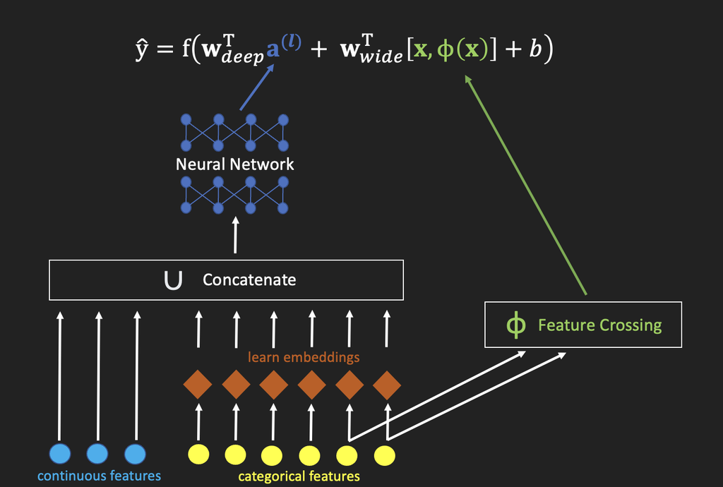

image source: author

More specifically:

- The Wide & Deep model is designed to solve “large-scale regression and classification problems with sparse inputs.”
- The *wide* portion of the model is a [Generalized Linear Model (GLM)](https://en.wikipedia.org/wiki/Generalized_linear_model).
- The *deep* part of the model is a [Feed-Forward (Dense) Neural Network](https://en.wikipedia.org/wiki/Feedforward_neural_network).
- The parameters of both parts (*wide* and *deep*) are optimized simultaneously during model training.
- Continuous input features are fed directly into the *deep* part of the model.
- Categorical input features are either:
  1. Embedded into a $k$-dimensional numeric representation then fed into the *deep* part of the model. These embeddings are learned directly during training. Embedding dimension $k$ is a hyperparameter to be chosen/optimized (i.e. not learned during training).
  2. Embedded into a $k$-dimensional numeric representation then fed into the *deep* part of the model **and** (independently and in parallel) feature-crossed and then fed into the *wide* part of the model.

     **Example**: categorical feature *[user_occupation]*…
     - …contributes 5-dimensional embedding $\Big(\text{[user_occupation]=='musician'}\Big)\rightarrow{}[-0.34,0.01,5.90,-6.94,1.12]$ as input to *deep* part
     - …contributes binary input $X_j=\Big(\text{[user_occupation]=='musician'}\Big) \in \{0,1\}$ as input to *wide* part
     - …contributes binary crossed feature $X_j=\Big(\text{[user_occupation]=='musician'}\&\text{[user_gender]=='female'}\Big) \in \{0,1\}$ as input to *wide* part
     - …contributes binary crossed feature $X_j=\Big(\text{[user_occupation]=='musician'}\&\text{[user_city]=='London'}\Big) \in \{0,1\}$, as input to *wide* part
- The outputs of the *deep* and *wide* components are then linearly combined (using weights $\mathbf{W}_{deep}$ and $\mathbf{W}_{wide}$ learned during training) and a chosen activation function (e.g. sigmoid for binary classification) is applied in order to generate the model output/prediction. A baseline/bias term $b$ (also learned during training) is also added into the linear combination.
- Many variants of this model exist, such as DeepFM ((Guo et al. 2017)), Deep & Cross Network ((Wang et al. 2021)), TODO…

# Deep & Cross Model

[back to contents]

The Deep & Cross (Wang et al. 2021) model … TODO

# 2-Tower Model

[back to contents]

TODO

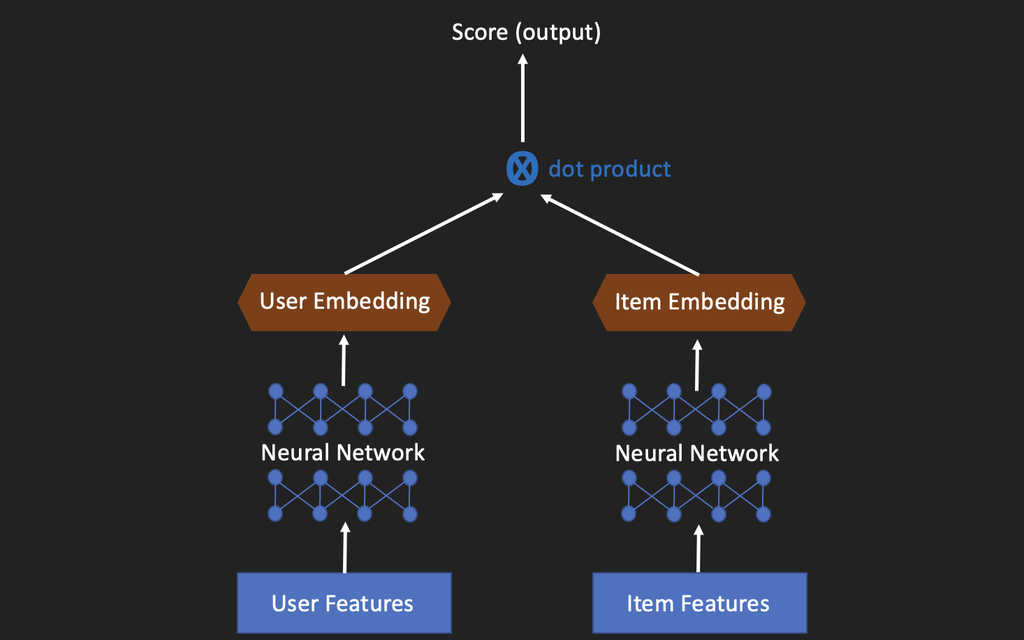

image source: author

[back to contents]

# Integrating Latent Factor Models with Arbitrary Models

[back to contents]

$$\begin{array}{lcl}
\hat{r}_{ij} &=& \underset{\text{main effects:}\\\text{user
generosity &}\\\text{item popularity}}{\underbrace{\quad o_i + p_j
\quad}} + \underset{\text{matrix factorization/}\\\text{latent factor
model}}{\underbrace{\quad \overrightarrow{u}_i \cdot
\overrightarrow{v}_j \quad}} + \beta
\space F\bigg(\underset{\text{content
model}}{\underbrace{\overrightarrow{c}_i^{(user)},
\overrightarrow{c}_j^{(item)}}}, \underset{\text{collaborative
model}}{\underbrace{\overrightarrow{r}_i^{(user)},
\overrightarrow{r}_j^{(item)}}}, \bigg)\\
\space &\space& \space \\
\hat{r}_{ij} &=& \text{predicted rating of item } j \text{ by
user } i\\
o_i &=& \text{user } i \text{ bias (e.g. user who rates all
items highly)} \\
p_j &=& \text{item } j \text{ bias (e.g. item that all users
rate highly)} \\
\overrightarrow{u}_i &=& \text{latent factor representation of
user } i\\
\overrightarrow{v}_j &=& \text{latent factor representation of
item } j \\
\beta &=& \text{adjustment/weight of non-latent portion of
model} \\
F() &=& \text{any chosen function (e.g. linear regression)} \\
\overrightarrow{c}_i^{(user)} &=& \text{user } i \text{
attribute/content vector} \\
\overrightarrow{c}_j^{(item)} &=& \text{item } j \text{
attribute/content vector} \\
\overrightarrow{r}_i &=& \text{user } i \text{ observed ratings
vector (row of user/item ratings matrix)} \\
\overrightarrow{r}_j &=& \text{item } j \text{ observed ratings
vector (column of user/item ratings matrix)} \\
\end{array}$$

This parameters of this entire model (including the latent factors $\overrightarrow{u}_i$ and $\overrightarrow{v}_j$) can be optimized simultaneously.

Some possible choices of function $F()$ are:

- Factorization Machine
- Multilayer Perceptron (dense neural network)

# Cascade Ranking

[back to contents]

TODO

see: https://arxiv.org/pdf/2210.09890.pdf

# References

Aggarwal, Charu C. 2016. *Recommender Systems - the Textbook*. Springer.

Armstrong, Robert. 2008. *The Long Tail: Why the Future of Business Is Selling Less of More*. *Canadian Journal of Communication*. Vol. 33. https://doi.org/10.22230/cjc.2008v33n1a1946.

Cheng, Heng-Tze, Levent Koc, Jeremiah Harmsen, Tal Shaked, Tushar Chandra, Hrishi Aradhye, Glen Anderson, et al. 2016. *Wide & Deep Learning for Recommender Systems*. arXiv. https://doi.org/10.48550/ARXIV.1606.07792.

Guo, Huifeng, Ruiming Tang, Yunming Ye, Zhenguo Li, and Xiuqiang He. 2017. *DeepFM: A Factorization-Machine Based Neural Network for CTR Prediction*. arXiv. https://doi.org/10.48550/ARXIV.1703.04247.

Kaminskas, Marius, and Derek Bridge. 2016. *Diversity, Serendipity, Novelty, and Coverage: A Survey and Empirical Analysis of Beyond-Accuracy Objectives in Recommender Systems*. *ACM Trans. Interact. Intell. Syst.* Vol. 7. New York, NY, USA: Association for Computing Machinery. https://doi.org/10.1145/2926720.

Rendle, Steffen. 2010. *Factorization Machines*. *2010 IEEE International Conference on Data Mining*.

Wang, Ruoxi, Rakesh Shivanna, Derek Cheng, Sagar Jain, Dong Lin, Lichan Hong, and Ed Chi. 2021. *DCN V2: Improved Deep & Cross Network and Practical Lessons for Web-Scale Learning to Rank Systems*. ACM. https://doi.org/10.1145/3442381.3450078.